# 2_ggplot2

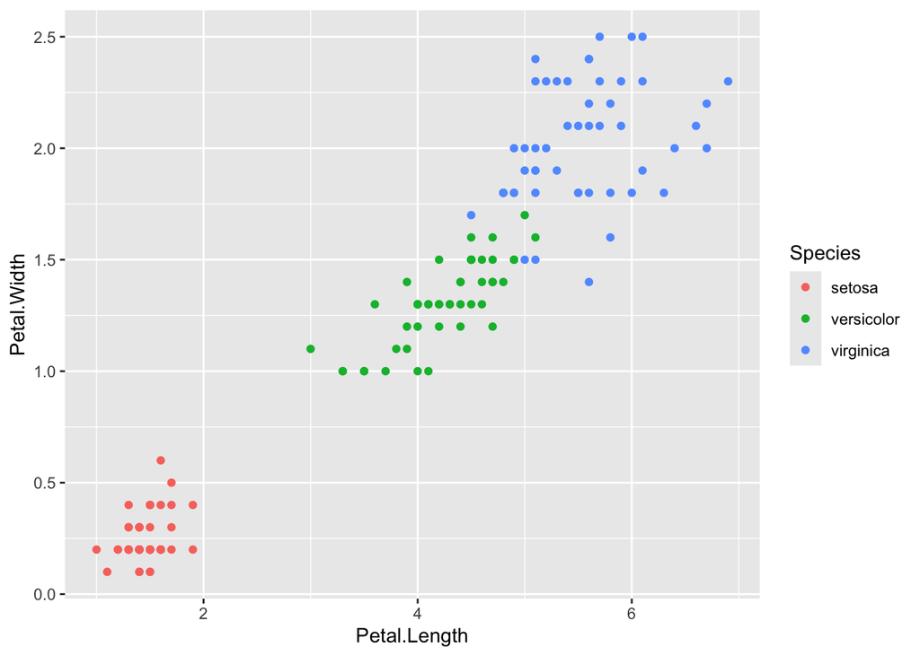

```r
p <- p + geom_point()
p
```

Hazlo en una linea

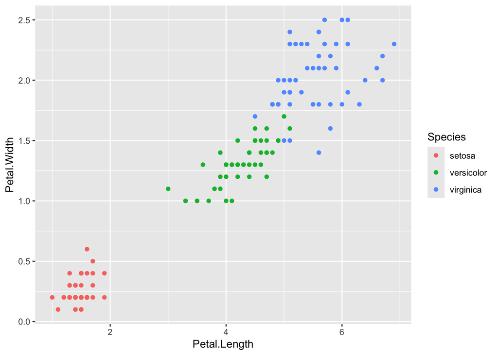

```r
ggplot(data=iris, aes(x = Petal.Length, y = Petal.Width, colour = Species)) + geom_point()
```

Transformaciones estadisticas de los datos

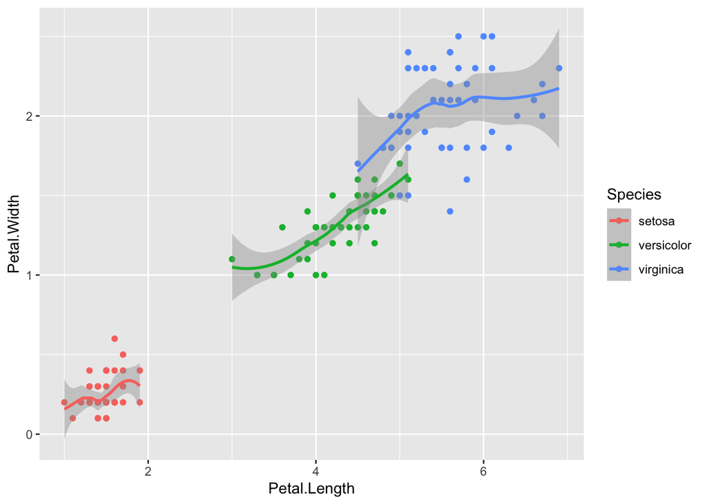

```r
p <- p + geom_smooth()
p
```

En una sola linea

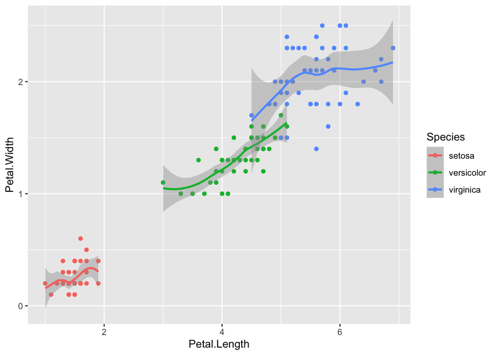

```r
ggplot(data=iris, aes(x = Petal.Length, y = Petal.Width, colour = Species)) +
  geom_point() +
  geom_smooth()
```

Facet grid (Cuadrícula de facetas) Vertical

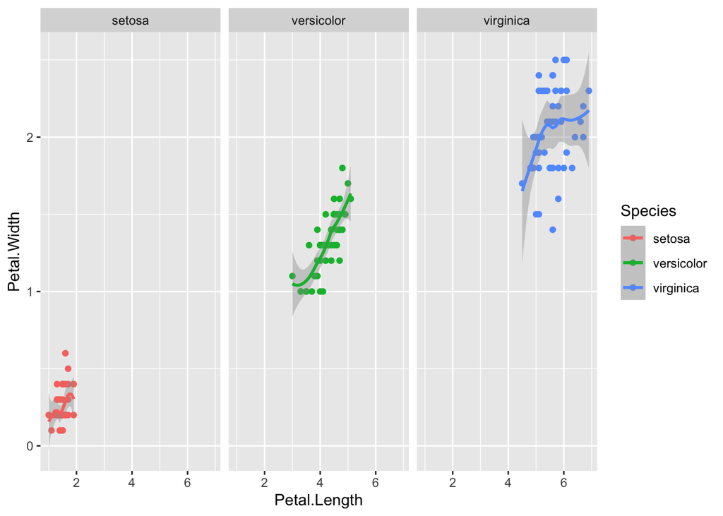

```r
ggplot(data=iris, aes(x = Petal.Length, y = Petal.Width, colour = Species)) +
  geom_point() +
  geom_smooth() +
  facet_grid(~ Species)
```

Horizontal

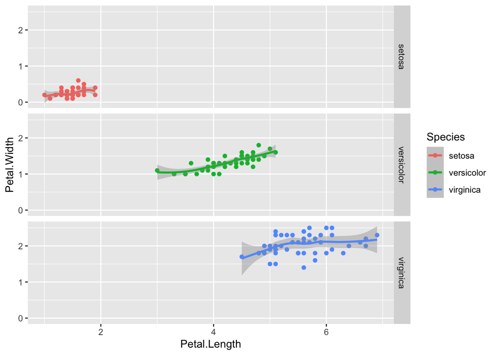

```r
ggplot(data=iris, aes(x = Petal.Length, y = Petal.Width, colour = Species)) +
  geom_point() +
  geom_smooth() +
  facet_grid(Species ~.)
```

Quitar leyenda

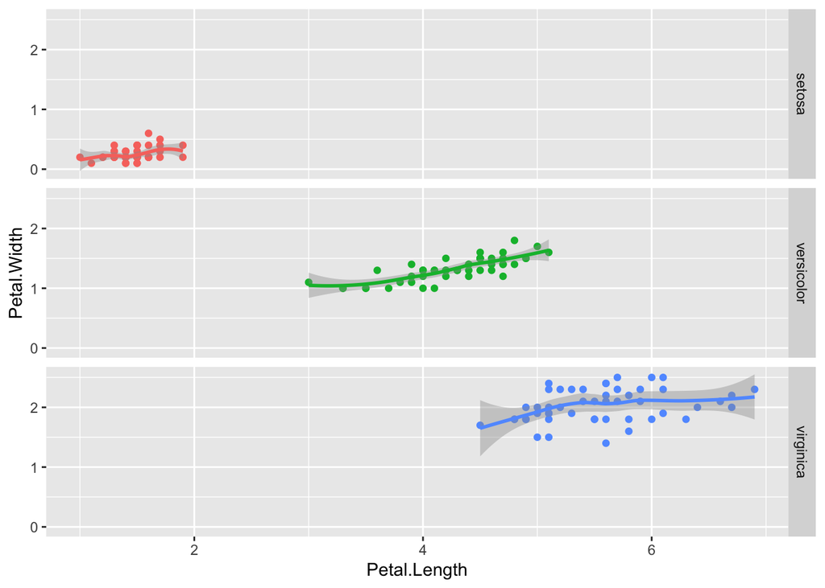

```r
ggplot(data=iris, aes(x=Petal.Length, y=Petal.Width, colour=Species)) +
  geom_point(show.legend = FALSE) +
  geom_smooth(show.legend = FALSE) +
  facet_grid(Species~.)
```

Cambio de temas https://ggplot2.tidyverse.org/reference/ggtheme.html

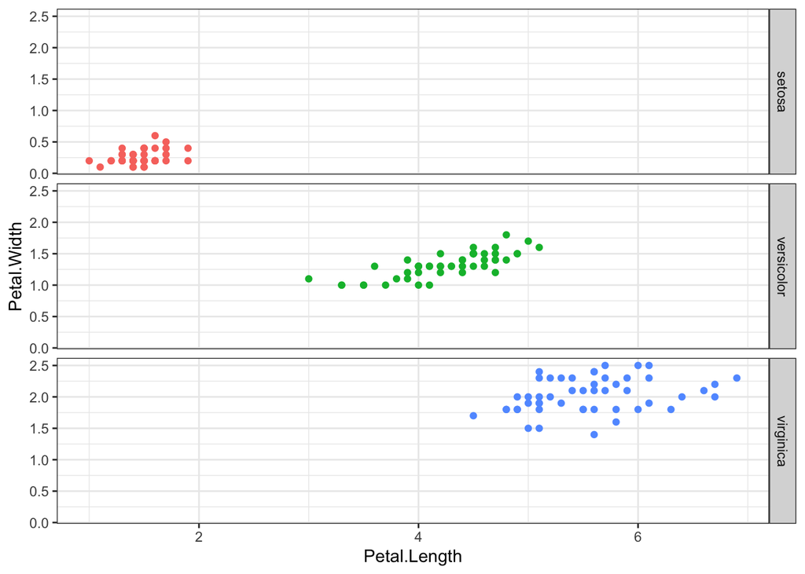

```r
ggplot(data=iris, aes(x = Petal.Length, y = Petal.Width, colour = Species)) +
  geom_point(show.legend = FALSE) +
  facet_grid(Species~.) +
  theme_bw()
```

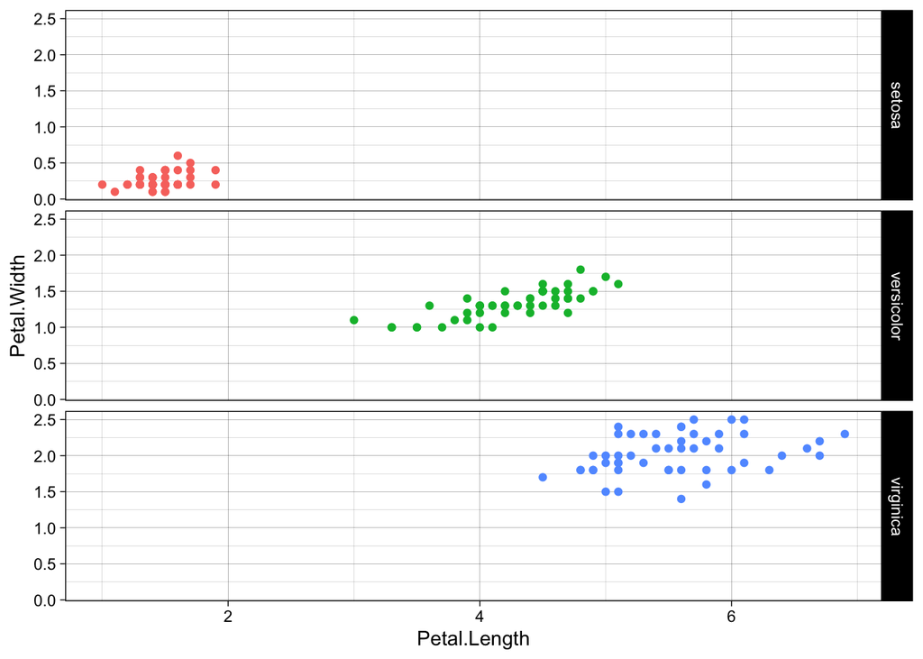

```r
ggplot(data=iris, aes(x = Petal.Length, y = Petal.Width, colour = Species)) +
  geom_point(show.legend = FALSE) +
  facet_grid(Species~.) +
  theme_linedraw()
```

Cambiar otros elementos en el tema

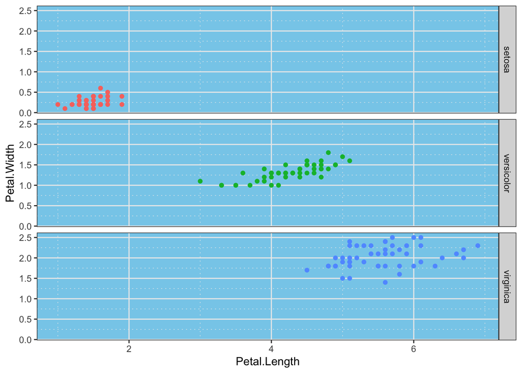

```r
ggplot(data=iris, aes(x = Petal.Length, y = Petal.Width, colour = Species)) +
  geom_point(show.legend = FALSE) +
  facet_grid(Species~.) +
  theme_bw() +
  theme(panel.background = element_rect(fill = "skyblue"), panel.grid.minor = element_line(linetype = "dotted"))
```

Guardar imagenes

En que directorio me encuentro

getwd()

Primera opcion

PNG con una resolucion de 300 px

```r
png("../plot/dot_plot_iris_data.png", width=10 *300, height=8*300, res= 300)

ggplot(data=iris, aes(x = Petal.Length, y = Petal.Width, colour = Species)) +
  geom_point(show.legend = FALSE) +
  facet_grid(Species~.) +
  theme_linedraw()

dev.off()
```

PDF (Imagen vectorizada)

```r
pdf("../plot/dot_plot_iris_data.pdf", width=10, height=8)

ggplot(data=iris, aes(x = Petal.Length, y = Petal.Width, colour = Species)) +
  geom_point(show.legend = FALSE) +
  facet_grid(Species~.) +
  theme_linedraw()

dev.off()
```

Segunda opcion con una funcion propia de ggplot2

```r
ggsave("../plot/dot_plot_iris_data.jpg", device= "jpg")
```

## Ejercicio 1

Crear datos “cabbage_exp”

cabbage_exp –> Es el recopilado de un experimento de un cultivo de “Col o repollo (cabbage)”. Fueron 2 condiciones C39 y C52; y se cortaron las coles a los dias 16, 20 y 21; se pesaron 10 coles de la condicion y se obtuvo la desviacion estandar y el error estandar de la media del peso.

cabbage_exp <- data.frame(Cultivar=c(rep(“c39”, 3), rep(“c52”, 3)), Date=rep(c(“d16”, “d20”, “d21”),2), Weight=c(3.18, 2.80, 2.74, 2.26, 3.11, 1.47), sd= c(0.9566144, 0.2788867, 0.9834181, 0.4452215, 0.7908505, 0.2110819), n=rep(10,6), se=c(0.30250803, 0.08819171, 0.31098410, 0.14079141, 0.25008887, 0.06674995))

Explorar datos

Gráfico de Bar plots basico, en el eje de las x=Date y y= Weight

Cambio de color de las barras, por ejemplo, azul

Cambio de tema

Grafico con barras apiladas coloreado por condicion, por ejemplo **Cultivar**

# Usa otra paleta de colores

# Añadir barras de error

#### Ejercicio: Scatter plots

#### Diapositivas: 36-38

#### Scatter plots basicos

ggplot(data= iris, aes(x= Petal.Length, y= Petal.Width)) + geom_point()

# Color por condicion

ggplot(data= iris, aes(x= Petal.Length, y= Petal.Width, colour=Species)) + geom_point()

# Forma por condicion

ggplot(data= iris, aes(x= Petal.Length, y= Petal.Width, shape=Species)) + geom_point()

# Forma y color por condicion

ggplot(data= iris, aes(x= Petal.Length, y= Petal.Width, shape=Species, colour=Species)) + geom_point()

# Cambiar los valores de forma

ggplot(data= iris, aes(x= Petal.Length, y= Petal.Width, shape=Species, colour=Species)) + geom_point() + scale_shape_manual(values=c(1,2,3))

# Cambiar colores manuales

ggplot(data= iris, aes(x= Petal.Length, y= Petal.Width, shape=Species, colour=Species)) + geom_point() + scale_shape_manual(values=c(1,2,3)) + scale_colour_manual(values=c(“deepskyblue”, “seagreen2”, “salmon”)) + theme_bw()

# Cambiar la posicion del recuadro de la leyenda y las etiquetas de los ejes

ggplot(data= iris, aes(x= Petal.Length, y= Petal.Width, shape=Species, colour=Species)) + geom_point() + scale_shape_manual(values=c(1,2,3)) + scale_colour_manual(values=c(“deepskyblue”, “seagreen2”, “salmon”)) + labs(title= “Taller ggplot RMB”, y= “Petal Width (cm)”, x= “Petal Length (cm)”, fill= ““) + theme_bw() + theme(legend.position=”bottom”)

#### Graficos Interactivos de ggplot:

#### Diapositivas: 39-61

# Instalar libreria

#install.packages(“esquisse”)

#Cargar libreria library(esquisse)

#Cargar datos esquisser(iris)

### Ejemplo: Histogramas

ggplot(iris) + aes(x = Sepal.Length) + geom_histogram(bins = 30L, fill = “#0c4c8a”) + theme_minimal()

ggplot(iris) + aes(x = Sepal.Length, fill = Species) + geom_histogram(bins = 30L) + scale_fill_hue() + theme_minimal()

### Ejemplo: Boxplots

ggplot(iris) + aes(x = ““, y = Sepal.Length, fill = Species) + geom_boxplot() + scale_fill_hue() + theme_minimal()

### Ejemplo: Densidad

ggplot(iris) + aes(x = Sepal.Length, fill = Species) + geom_density(adjust = 1L) + scale_fill_hue() + theme_minimal()

ggplot(iris) + aes(x = Sepal.Length, fill = Species) + geom_density(adjust = 1L) + scale_fill_viridis_d(option = “viridis”) + labs(x = “Densidad”, title = “Gráfico de Densidad”, subtitle = “Taller ggplot RMB”) + theme_minimal()

ggplot(iris) + aes(x = Sepal.Length, fill = Species) + geom_density(adjust = 1L) + scale_fill_viridis_d(option = “viridis”) + labs(x = “Densidad”, title = “Gráfico de Densidad”, subtitle = “Taller ggplot RMB”) + theme_minimal()